# Analysis of crashes near speed cameras

```r
# filling in NAs for Crashes column
camera_crashes <- mutate(camera_crashes, Crashes = ifelse(is.na(Crashes), 0, Crashes))

# Setting first values in data set for CameraLive so fill function will work correctly
camera_crashes$CameraLive[1:4] <- 0

# Making sure each Camera's live date is filled in so fill function will work properly
camera_crashes$CameraLive[camera_crashes$Date == "2018-02-21" & camera_crashes$ClosestCamera == "CHI173"] <- 1

camera_crashes$CameraLive[camera_crashes$Date == "2018-08-29" & camera_crashes$ClosestCamera %in% c("CHI174", "CHI175","CHI177")] <- 1

# fill in the NAs for the CameraLive column
camera_crashes <- camera_crashes %>%
  group_by(ClosestCamera) %>%
  fill(CameraLive) %>%
  ungroup()
```

```r
# Building a crash month column off of the date column for random sampling
camera_crashes$Month <- substr(camera_crashes$Date,6,7)

camera_crashes$CameraLive <- as.factor(camera_crashes$CameraLive)

camera_crashes$Month <- as.factor(camera_crashes$Month)
```

Per Chicago data portal: “Data from E-Crash are available for some police districts in 2015, but citywide data are not available until September 2017”. Let’s make the start of our sample be 9-2017 so we don’t skew our dataset

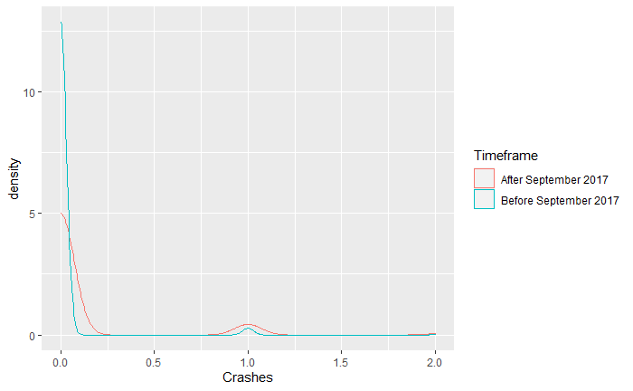

```r
t <- camera_crashes %>%
  filter(ClosestCamera != "CHI173", Date < "2018-08-29") %>%
  mutate(Timeframe = ifelse(Date <= "2017-09-01", "Before September 2017", "After September 2017"))

meancrashes <- t %>%
  group_by(Timeframe) %>%
  summarise(
    Mean = mean(Crashes)
  )
ggplot(data=t,aes(x=Crashes))+
  geom_density(aes(color=Timeframe))
```

Filter our dataset so we only have data past 9/1/2017

```r
camera_crashes_t <- camera_crashes %>%
  filter(Date >= "2017-09-01")
```

Let’s build a MonthYear column for potential use later.

```r
camera_crashes_t$Year <-substr(camera_crashes_t$Date,1,4)
camera_crashes_t$Month <- as.character(camera_crashes_t$Month)
camera_crashes_t$MonthYear <- paste(camera_crashes_t$Year,"-",camera_crashes_t$Month,"-01",sep="")
camera_crashes_t$MonthYear <- as.Date(camera_crashes_t$MonthYear)
```

Let’s visualize how monthly aggregate crashes near speed cameras have changed over time.

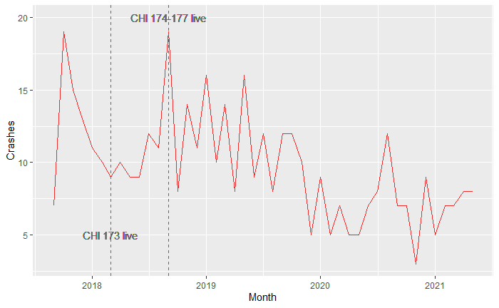

```r
camera_crashes_month <- camera_crashes_t %>%
  group_by(MonthYear, Month) %>%
  summarise(
    Crashes = sum(Crashes)
  ) %>%
  ungroup()
ggplot(data=camera_crashes_month, aes(x=MonthYear,y=Crashes))+
  geom_line(aes(group=1), color="firebrick2")+
  geom_vline(aes(xintercept=as.Date("2018-09-01")), color = "grey40", linetype = "dashed")+
  geom_vline(aes(xintercept=as.Date("2018-03-01")), color = "grey40", linetype = "dashed")+
  geom_text(aes(x=as.Date("2018-09-01"), y=20,label="CHI 174-177 live"), color="grey40")+
  geom_text(aes(x=as.Date("2018-03-01"), y=5, label="CHI 173 live"), color="grey40")+
  scale_x_date(name = "Month")
```

```r
NA
```

I want to see what the current “mix” of our dataset is pre/post camera live.

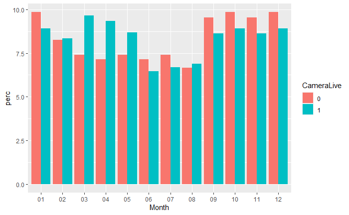

```r
t <- camera_crashes_t %>%
  group_by(Month,CameraLive)%>%
  summarise(
    Frequency = n()
  )
s <- camera_crashes_t %>%
  group_by(CameraLive)%>%
  summarise(
    c=n()
  )
a <- left_join(t,s,by="CameraLive")

a$perc <- a$Frequency/a$c*100

ggplot(data=a, aes(x=Month, y=perc))+
  geom_bar(aes(fill=CameraLive), stat="identity", position = "dodge")
```

Sample data points for each (Month, Camera) group. This should ensure we have an even spread of cameras/months in our sample.

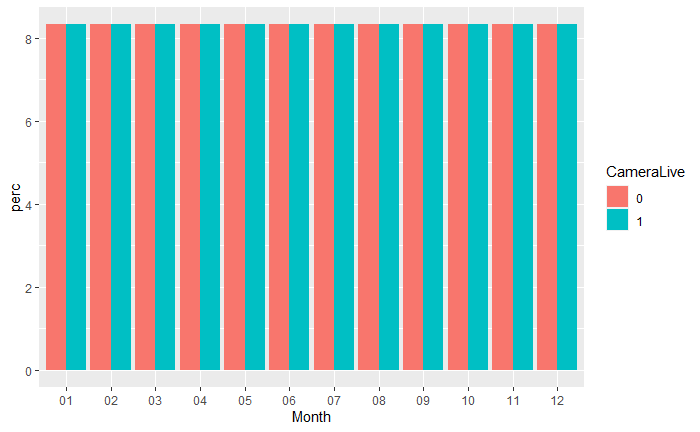

```r
d1 <- camera_crashes_t %>%
  filter(CameraLive == 0, ClosestCamera != "CHI173") %>%
  group_by(Month,ClosestCamera) %>%
  sample_n(28)

d2 <- camera_crashes_t %>%
  filter(CameraLive == 1, ClosestCamera != "CHI173") %>%
  group_by(Month, ClosestCamera) %>%
  sample_n(31)

new_df <- rbind(d1,d2)


t <- new_df %>%
  group_by(Month,CameraLive)%>%
  summarise(
    Frequency = n()
  )
s <- new_df %>%
  group_by(CameraLive)%>%
  summarise(
    c=n()
  )
a <- left_join(t,s,by="CameraLive")

a$perc <- a$Frequency/a$c*100

# let's see what it looks like for cameras too
c <- new_df %>%
  group_by(ClosestCamera,Month,CameraLive)%>%
  summarise(
    Frequency = n()
  )
d <- new_df %>%
  group_by(CameraLive)%>%
  summarise(
    c=n()
  )
e <- left_join(c,d,by="CameraLive")

e$perc <- e$Frequency/e$c*100

e <- e %>%
  group_by(ClosestCamera, CameraLive) %>%
  summarise(
    Percent = sum(perc)
  )
# Let's see our sample mix for months
ggplot(data=a, aes(x=Month, y=perc))+
  geom_bar(aes(fill=CameraLive), stat="identity", position = "dodge")
```

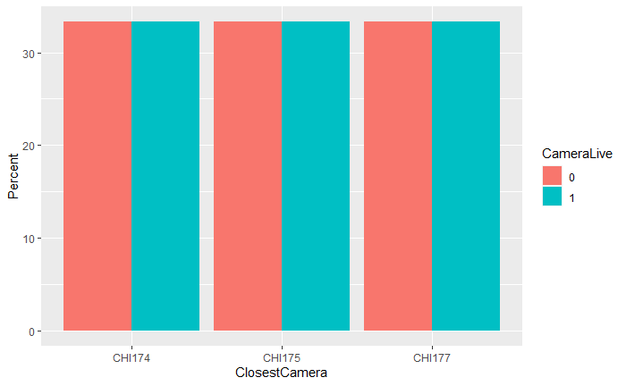

```r
# Let's see our sample mix for cameras
ggplot(data=e, aes(x=ClosestCamera, y=Percent))+
  geom_bar(aes(fill=CameraLive), stat="identity", position = "dodge")
```

```r
d1_173 <- camera_crashes_t %>%
  filter(CameraLive == 0, ClosestCamera == "CHI173") %>%
  group_by(Month,ClosestCamera) %>%
  sample_n(20)

d2_173 <- camera_crashes_t %>%
  filter(CameraLive == 1, ClosestCamera == "CHI173", !(Month %in% c("03","04","05","06","07","08"))) %>%
  group_by(Month, ClosestCamera) %>%
    sample_n(31)

new_df_173 <- rbind(d1_173,d2_173)
```

Let’s grab sample means before/after cameras are live.

```r
new_df %>%
  group_by(ClosestCamera,CameraLive) %>%
  summarise(
    AvgCrashes = mean(Crashes)
  )
```

| ClosestCamera | CameraLive | AvgCrashes |
| --- | --- | --- |
| CHI174 | 0 | 0.04166667 |
| CHI174 | 1 | 0.03494624 |
| CHI175 | 0 | 0.05654762 |
| CHI175 | 1 | 0.02688172 |
| CHI177 | 0 | 0.18750000 |
| CHI177 | 1 | 0.15860215 |

```r
new_df_173 %>%
  group_by(ClosestCamera,CameraLive) %>%
  summarise(
    AvgCrashes = mean(Crashes)
  )
```

| ClosestCamera | CameraLive | AvgCrashes |
| --- | --- | --- |
| CHI173 | 0 | 0.10000000 |
| CHI173 | 1 | 0.07526882 |

```r
new_df <- rbind(new_df,new_df_173)
new_df %>%
  group_by(ClosestCamera,CameraLive) %>%
  summarise(
    AvgCrashes = mean(Crashes)
  )
```

| ClosestCamera | CameraLive | AvgCrashes |
| --- | --- | --- |
| CHI173 | 0 | 0.10000000 |
| CHI173 | 1 | 0.07526882 |
| CHI174 | 0 | 0.04166667 |
| CHI174 | 1 | 0.03494624 |
| CHI175 | 0 | 0.05654762 |
| CHI175 | 1 | 0.02688172 |
| CHI177 | 0 | 0.18750000 |
| CHI177 | 1 | 0.15860215 |

Ideally I’d like to do a formal test of significance between the two samples (e.g. t test). The density plot, however, shows that our data is clearly not normally distributed.

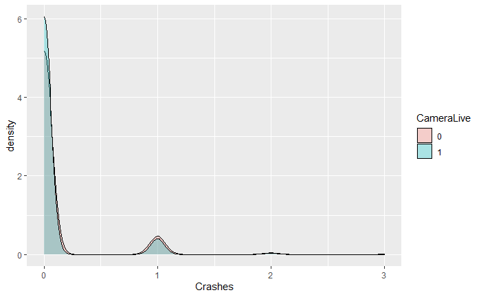

```r
ggplot(data=new_df, aes(x=Crashes))+
  geom_density(aes(fill=CameraLive),alpha=0.3)
```

If we aggregate by month, our crashes resemble something closer to a normal distribution.

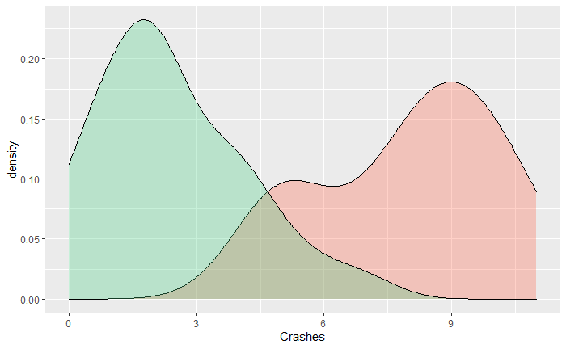

```r
new_df_month <- new_df %>%
  filter(ClosestCamera %in% c("CHI177","CHI175","CHI174")) %>%
  group_by(MonthYear, CameraLive) %>%
  summarise(
    Crashes = sum(Crashes)
  ) %>%
  ungroup()
before <- filter(new_df_month, CameraLive == 0)
after <- filter(new_df_month, CameraLive ==1)

ggplot(data=before)+
  geom_density(aes(x=Crashes),fill="tomato1",alpha=0.3)+
  geom_density(data=after,aes(x=Crashes),fill="seagreen3",alpha=0.3)
```

```r
res <- t.test(before$Crashes,after$Crashes)
res
```

```
    Welch Two Sample t-test

data:  before$Crashes and after$Crashes
t = 8.3031, df = 16.732, p-value = 2.463e-07
alternative hypothesis: true difference in means is not equal to 0
95 percent confidence interval:
 4.166527 7.009943
sample estimates:
mean of x mean of y
 8.000000  2.411765
```

```r
lm <- lm(Crashes~CameraLive, data = camera_crashes_t)
summary(lm)
```

```
Call:
lm(formula = Crashes ~ CameraLive, data = camera_crashes_t)

Residuals:
     Min       1Q   Median       3Q      Max
-0.09849 -0.07517 -0.07517 -0.07517  2.92483

Coefficients:
             Estimate Std. Error t value Pr(>|t|)
(Intercept)  0.098491   0.008395  11.732   <2e-16 ***
CameraLive1 -0.023317   0.009577  -2.435   0.0149 *
---
Signif. codes:  0 ‘***’ 0.001 ‘**’ 0.01 ‘*’ 0.05 ‘.’ 0.1 ‘ ’ 1

Residual standard error: 0.2979 on 5434 degrees of freedom
Multiple R-squared:  0.00109,   Adjusted R-squared:  0.0009058
F-statistic: 5.928 on 1 and 5434 DF,  p-value: 0.01494
```

Exploring Poisson distribution:

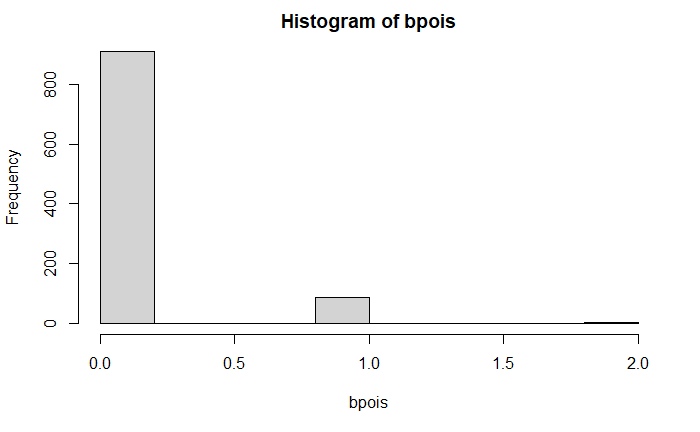

```r
bpois <- rpois(n=1000, lambda = mean(filter(new_df, CameraLive==0)$Crashes))
hist(bpois)
```

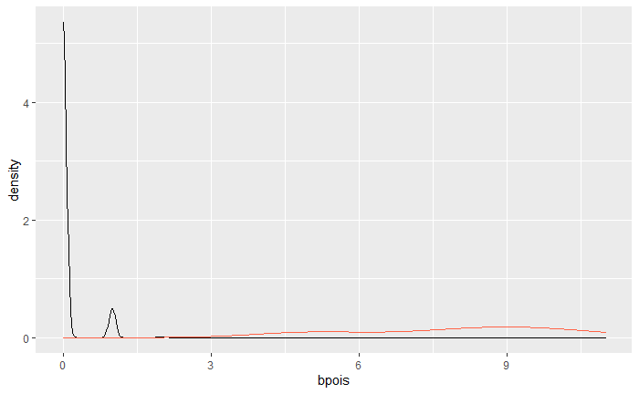

```r
bpoisdf <- data.frame(bpois)

ggplot(data=bpoisdf)+
  geom_density(aes(x= bpois))+
  geom_density(data=before, aes(x=Crashes),color="tomato1",alpha=0.25)
```

Time series decomposition:

```r
crashes_ts <- ts(camera_crashes_month$Crashes, frequency = 12)
crashes_ts
```

```
  Jan Feb Mar Apr May Jun Jul Aug Sep Oct Nov Dec
1   7  19  15  13  11  10   9  10   9   9  12  11
2  19   8  14  11  16  10  14   8  16   9  12   8
3  12  12  10   5   9   5   7   5   5   7   8  12
4   7   7   3   9   5   7   7   8   8
```

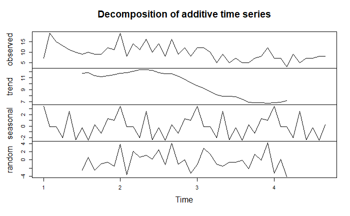

```r
crashes_decompose <- decompose(crashes_ts)
plot(crashes_decompose)
```

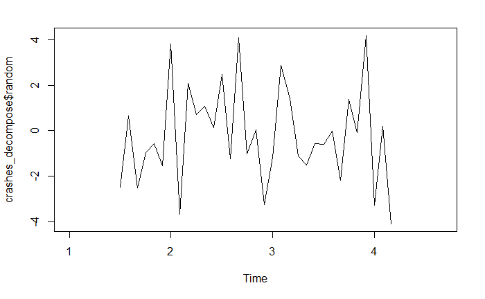

```r
res <- data.frame(Residual = crashes_decompose$random)
plot(crashes_decompose$random)
```

```r
mean(crashes_decompose$random, na.rm = "TRUE")
```

```
[1] -0.2054398
```

```r
checkresiduals(crashes_decompose$random)
```

[output not shown]